# Huang.X_Exercise9

2024-03-24

1. Dialogue
1. Most Common Words

```r
# Load libraries and data
library(ggplot2)
library(tidyverse)
library(tidytext)
data = read.csv('/Users/Administrator/Documents/GitHub/Huang_Xinyao/course_content/Exercises/09_moviescripts_GRADED/data/dialogue.csv')
```

```r
# Define cleaning functions
clean_text <- function(text) {
  # Convert text to lowercase
  text <- tolower(text)
  # Remove punctuation
  text <- gsub("[[:punct:]]", "", text)
  # Remove numbers
  text <- gsub("\\d+", "", text)
  # Remove white space
  text <- trimws(text)
  return(text)
}

# Apply cleaning functions to the dialogue column
cleaned_data <- data %>%
  mutate(cleaned_dialogue = map_chr(Dialogue, clean_text)) %>%
  filter(!str_detect(cleaned_dialogue, "^$"))

# Tokenize the cleaned dialogue into individual words
cleaned_words <- cleaned_data %>%
  unnest_tokens(word, cleaned_dialogue)
```

```r
# Define the stop words list
stop_words <- data.frame(word = tm::stopwords("en"))

# Remove common stop words
cleaned_words <- cleaned_words %>%
  anti_join(stop_words)
# Count the frequency of each word
cleaned_word_freq <- cleaned_words %>%
  count(word, sort = TRUE)
```

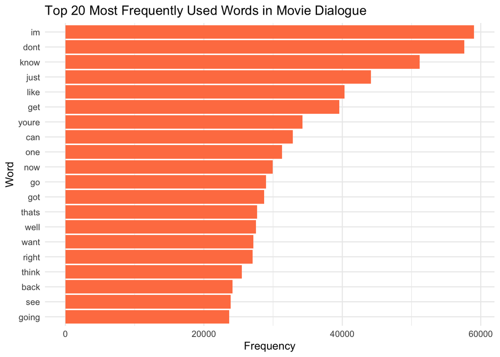

```r
# Visualize the top 20 most frequently used words
top_20_cleaned_words <- cleaned_word_freq %>%
  slice_max(n = 20, order_by = n) %>%
  ggplot(aes(x = reorder(word, n), y = n)) +
  geom_bar(stat = "identity", fill = "coral") +
  coord_flip() +
  labs(title = "Top 20 Most Frequently Used Words in Movie Dialogue",
       x = "Word",
       y = "Frequency") +
  theme_minimal()

# Display the plot
print(top_20_cleaned_words)
```

1. b) Word Cloud

```r
library(wordcloud)
library(tokenizers)
library(dplyr)
library(tm)
metadata <- read.csv("/Users/Administrator/Documents/GitHub/Huang_Xinyao/course_content/Exercises/09_moviescripts_GRADED/data/metadata.csv")
```

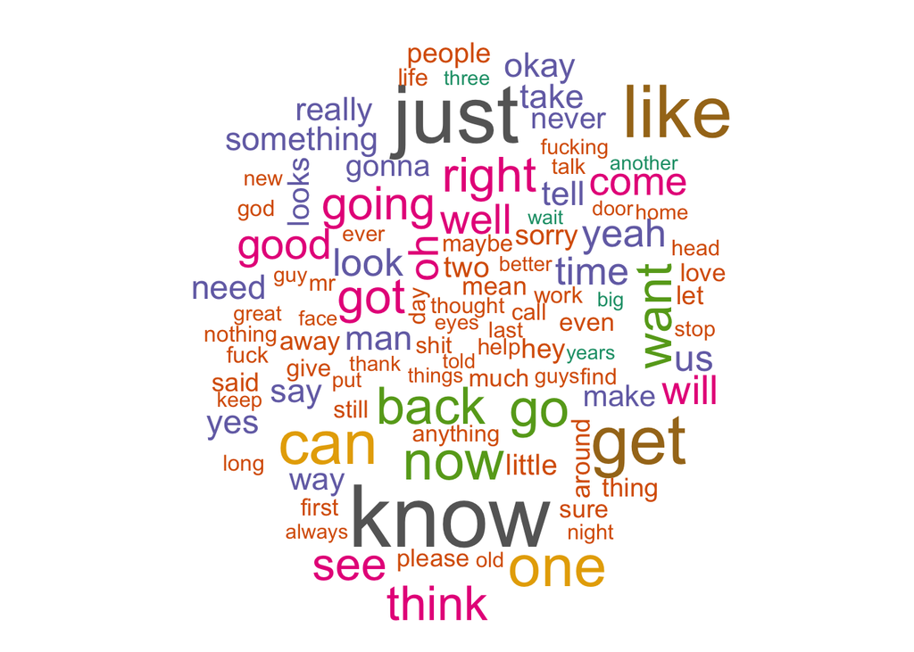

```r
# In this part, I want to filter movies that arae released after 2000
movies_after_2000 <- subset(metadata, as.integer(imdb_release_date) > 2000)

# Merge metadata with dialogue data
merged_data_2000 <- merge(movies_after_2000, data, by.x = 'file_name', by.y = "movie_id")
dialogue_concatenated <- merged_data_2000 %>%
  group_by(file_name) %>%
  summarise(AllDialogue = paste(Dialogue, collapse = " "))

# Tokenize the concatenated dialogue into words
words <- unlist(tokenize_words(dialogue_concatenated$AllDialogue))

# Remove stop words
stop_words <- stopwords("en")
words <- words[!tolower(words) %in% stop_words]

# Count the frequency of each word
word_freq <- table(words)

# Select the top 200 most frequent words
top_words <- head(sort(word_freq, decreasing = TRUE), 100)

# Create a word cloud from the top 200 most frequent words
wordcloud(words = names(top_words), freq = top_words, min.freq = 1, colors = brewer.pal(8, "Dark2"))
```

As we can see, the most frequently used words are pretty much the same regardless of the release date of the movies.

1. 3. Success in Words

```r
merged_data <- merge(metadata, data, by.x = 'file_name', by.y = "movie_id")
```

```r
# I measured the success of the movie by the popularity. If the popularity >= 27.892, then it's considered successful, otherwise unsuccessful, which separated the movies into two sets with roughly the same size.
success_data <- merged_data %>%
   mutate(whether_success = ifelse(popularity >= 27.892, "successful", "unsuccessful"))

# Tokenize the cleaned dialogue into individual words
success_words <- success_data %>%
  unnest_tokens(word, Dialogue)

# Remove common stop words
stop_words <- data.frame(word = tm::stopwords("en"))
success_words <- success_words %>%
  anti_join(stop_words)
# Count the frequency of each word
word_freq <- success_words %>%
  count(whether_success, word, sort = TRUE)
```

```r
# Select the top 25 words for each success category
top_words <- word_freq %>%
  group_by(whether_success) %>%
  slice_head(n = 15)
```

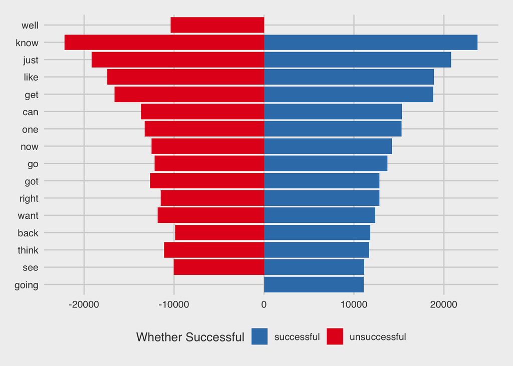

```r
# Create a pyramid plot
library(ggthemes)
ggplot(top_words, aes(x = reorder(word, n),
                  y = n, fill = whether_success)) +
  geom_bar(data = filter(top_words, whether_success == "successful"), stat = "identity") +
  geom_bar(data = filter(top_words, whether_success == "unsuccessful"), stat = "identity", aes(y=-n)) +
  scale_fill_brewer(palette = "Set1", direction=-1) +
  scale_y_continuous(breaks=seq(-30000,30000,10000), labels=seq(-30000,30000,10000)) +
  theme_fivethirtyeight() +
  coord_flip() +
  labs(fill = "Whether Successful")
```

1. 4. Profanity

```r
# Read text and create a list of profanities
profanity_list <- readLines('/Users/Administrator/Downloads/profanity_list.txt')
# Merge data
merged_data <- merge(metadata, data, by.x = 'file_name', by.y = "movie_id")
merged_words <- merged_data %>%
  unnest_tokens(word, Dialogue)

# Count the frequency of profanity words in each movie
profanity_counts <- merged_words %>%
  filter(word %in% profanity_list) %>%
  count(file_name, word)

# Calculate the profanity score for each movie
movie_profanity_score <- profanity_counts %>%
  group_by(file_name) %>%
  summarise(profanity_score = sum(n))

# Sort the movies based on their profanity score and visualize the top 10
top_10_movies <- movie_profanity_score %>%
  arrange(desc(profanity_score)) %>%
  head(10)
```

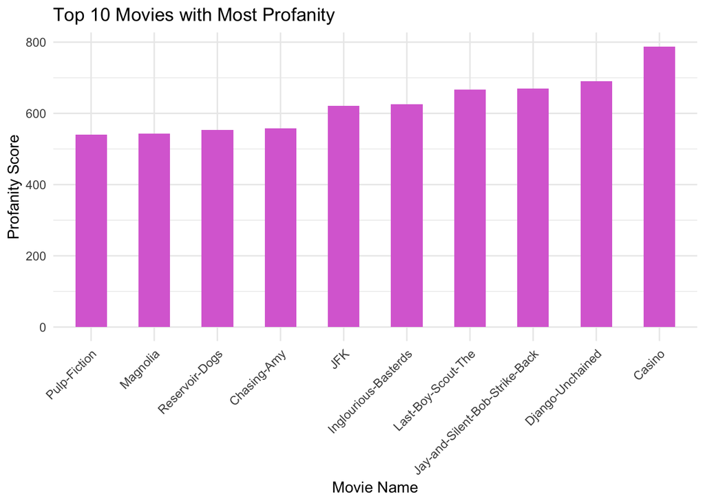

```r
# Create a bar plot to visualize the profanity scores of the top 10 movies
ggplot(top_10_movies, aes(x = reorder(file_name, profanity_score), y = profanity_score)) +
  geom_bar(stat = "identity", fill = "orchid", width = 0.5) +
  labs(title = "Top 10 Movies with Most Profanity",
       x = "Movie Name",
       y = "Profanity Score") +
  theme_minimal() +
  theme(axis.text.x = element_text(angle = 45, hjust = 1))
```

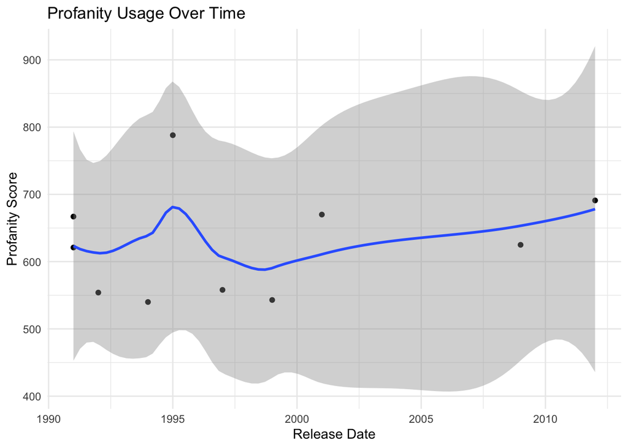

```r
# Plot the profanity score against the release date of the movie
top_10_movies_with_date <- merge(top_10_movies, metadata, by = 'file_name')
ggplot(top_10_movies_with_date, aes(x = imdb_release_date, y = profanity_score)) +
  geom_point() +
  geom_smooth(method = "loess") +
  labs(x = "Release Date", y = "Profanity Score", title = "Profanity Usage Over Time") +
  theme_minimal()
```

1. 5. Simplicity is a Virtue

```r
library(koRpus)
require(quanteda.textstats)
# Group the data by movie
grouped_data <- merged_data %>%
  group_by(file_name) %>%
  summarize(combined_dialogue = paste(Dialogue, collapse = " "))
```

```r
# Calculate Flesch Reading Ease scores for each movie
grouped_data <- grouped_data %>%
  mutate(flesch_scores = textstat_readability(combined_dialogue, measure = "Flesch"))
merged_data_readability <- merge(metadata, grouped_data, by = 'file_name')
```

```r
# Obtain the linear regression model
linear_model <- lm(vote_average ~ flesch_scores$Flesch, data = merged_data_readability)

# Print the summary of the linear regression model
print(summary(linear_model))
```

```
##
## Call:
## lm(formula = vote_average ~ flesch_scores$Flesch, data = merged_data_readability)
##
## Residuals:
##     Min      1Q  Median      3Q     Max
## -6.7612 -0.5234  0.0488  0.6300  1.8862
##
## Coefficients:
##                      Estimate Std. Error t value Pr(>|t|)
## (Intercept)          5.938885   0.590098  10.064   <2e-16 ***
## flesch_scores$Flesch 0.009555   0.006568   1.455    0.146
## ---
## Signif. codes:  0 '***' 0.001 '**' 0.01 '*' 0.05 '.' 0.1 ' ' 1
##
## Residual standard error: 0.9153 on 894 degrees of freedom
##   (1 observation deleted due to missingness)
## Multiple R-squared:  0.002362,   Adjusted R-squared:  0.001246
## F-statistic: 2.116 on 1 and 894 DF,  p-value: 0.1461
```

[figure not shown]

```r
# Visualize the relationship using a scatter plot
ggplot(merged_data_readability, aes(x = flesch_scores$Flesch, y = vote_average)) +
  geom_point() +
  geom_smooth(method = "lm", se = FALSE) +
  labs(title = "Relationship between Readability Score and IMDb Vote Average",
       x = "Readability Score",
       y = "IMDb Vote Average") +
  theme_minimal()
```

There seems to be a positive correlation between the readability of the movie scripts and the IMDb vote average, which means that the easier the movie lines to understand, more likely the movie will be popular. However the p value suggested that the correlation may not be significant.

2. 1. Defining words

```r
# Load required libraries
library(tm)
library(dplyr)
library(tidyr)
library(quanteda)
# Preprocess the data
merged_data <- merge(metadata, data, by.x = 'file_name', by.y = "movie_id")
```

```r
grouped_data <- merged_data %>%
  group_by(file_name) %>%
  summarize(combined_dialogue = paste(Dialogue, collapse = " "))
```

```r
grouped_data_with_genre <- grouped_data %>%
  inner_join(metadata, by = "file_name") %>%
  select(file_name, combined_dialogue, genres) %>%
  distinct()  # Remove duplicate entries
```

```r
grouped_data_with_genre <- grouped_data_with_genre %>%
  mutate(genres = strsplit(genres, ", ")) %>%
  unnest(genres) %>%
  unnest_tokens(word, combined_dialogue)
```

```r
# Calculate TF-IDF measure
tfidf_data <- grouped_data_with_genre %>%
  count(genres, word) %>%
  bind_tf_idf(word, genres, n)
# Select the top defining words for each genre
top_words <- tfidf_data %>%
  group_by(genres) %>%
  top_n(3, wt = tf_idf)
```

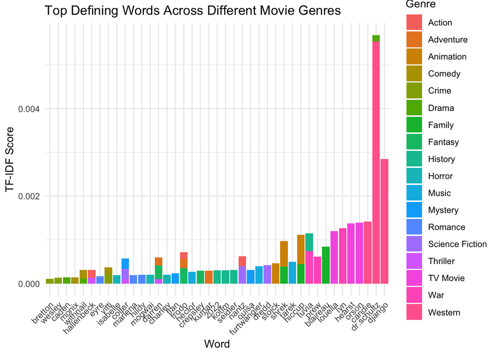

```r
ggplot(top_words, aes(x = reorder(word, tf_idf), y = tf_idf, fill = genres)) +
  geom_bar(stat = "identity") +
  labs(title = "Top Defining Words Across Different Movie Genres",
       x = "Word",
       y = "TF-IDF Score",
       fill = "Genre") +
  theme_minimal() +
  theme(axis.text.x = element_text(angle = 45, hjust = 1))
```

2.b) Emotions

```r
# import nrc lexicon
library(tidyverse)
library(tidytext)
nrc_lexicon <- get_sentiments("nrc")
```

```r
# Since my laptop keeps crashing when I tried to deal with the whole dataset, I only selected the movies after 2000 for this part of work. The other workflow should be the same. Hope that's fine.
grouped_data_2000 <- merged_data_2000 %>%
  group_by(file_name) %>%
  summarize(combined_dialogue = paste(Dialogue, collapse = " "))

# Perform an inner join to merge the two files based on a common identifier
data_2000 <- inner_join(grouped_data_2000, metadata, by = 'file_name')
selected_data <- data_2000[, c("file_name", "combined_dialogue", "genres")]
```

```r
selected_data <- selected_data %>%
  mutate(genres = strsplit(genres, ", ")) %>%
  unnest(genres)
```

```r
tokenized_by_genre <- selected_data %>%
  unnest_tokens(word, combined_dialogue)
```

```r
# Join with the NRC lexicon to identify emotions
data_emotions <- tokenized_by_genre %>%
  inner_join(nrc_lexicon, by = "word") %>%
  select(genres, word, sentiment) %>%
  distinct()  # Remove duplicate entries
# Count the occurrences of each emotion within each genre
emotion_counts <- data_emotions %>%
  count(genres, sentiment) %>%
  spread(sentiment, n, fill = 0)  # Spread sentiment categories into separate columns

emotion_counts <- emotion_counts %>%
  select(-negative, -positive)
```

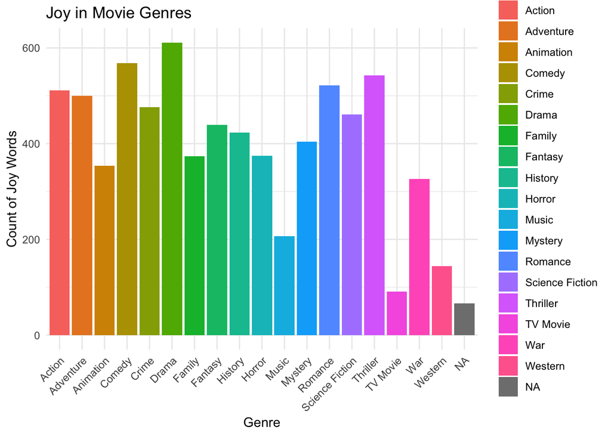

```r
# Visualize the relationship between emotions (Joy) and movie genres
ggplot(emotion_counts, aes(x = genres, y = joy, fill = genres)) +
  geom_bar(stat = "identity") +
  labs(title = "Joy in Movie Genres", x = "Genre", y = "Count of Joy Words") +
  theme_minimal() +
  theme(axis.text.x = element_text(angle = 45, hjust = 1))
```

```r
emotion_counts <- emotion_counts %>%
  mutate(max_emotion = apply(emotion_counts[, -1], 1, function(row) names(which.max(row))))

emotion_counts <- emotion_counts %>%
  filter(row_number() > 1) %>%  # Filter to keep rows starting from the second row
  rowwise() %>%
  mutate(max_value = max(c_across(starts_with("anger"):ends_with("trust"))))
```

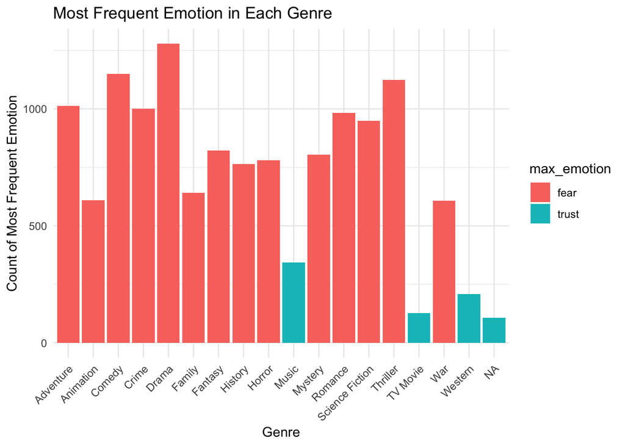

```r
# Plot the most frequent emotion in each genre
ggplot(emotion_counts, aes(x = genres, y = max_value, fill = max_emotion)) +
  geom_bar(stat = "identity") +
  labs(title = "Most Frequent Emotion in Each Genre",
       x = "Genre",
       y = "Count of Most Frequent Emotion") +
  theme_minimal() +
  theme(axis.text.x = element_text(angle = 45, hjust = 1))
```

This graph records the most frequently expressed emotion for each genre. From the graph, we can see that almost all the genres have the ‘fear’ sentiment the most. However, for music, tv movie, and western movie, they are more likely to show ‘trust’ in their dialogues.